# pearse_package

Abby Pearse

2025-12-01

## phyloseq: exploring microbiome profiles in R

Phyloseq is a package that is incredibly useful for analyzing phylogenetic sequencing data stored in an OTU (Operational Taxonomic Unit).

This package has a wide range of uses, including (but not limited to): * calculating abundance and related data * calculating supported distance methods (ie, UniFrac) * ordination * microbiome plot functions

Github for additional information is https://github.com/joey711/phyloseq/blob/master/inst/extdata/phyloseq.png

To install phyloseq, use the following code:

```r
if(!requireNamespace("BiocManager")){
  install.packages("BiocManager")
}
BiocManager::install("phyloseq")
library(phyloseq)
```

## **Importing data**

Phyloseq is able to recognize microbiome data that is formatted in different ways, and includes tools to construct a ‘phyloseq object’ using what are called ‘constructors’:

- otu_table = works on a numeric matrix
  - OTU table is a matrix showing abundance of different microbial groups
- sample_data = works on data frame containing sample information
- tax_table = taxonomic data on each sample

This is a tutorial modified from https://joey711.github.io/phyloseq/import-data.html. Code used to create the physeq object can be found at the end of this document.

```
## phyloseq-class experiment-level object
## otu_table()   OTU Table:         [ 10 taxa and 10 samples ]
## tax_table()   Taxonomy Table:    [ 10 taxa by 7 taxonomic ranks ]
```

## **Visualizing Taxonomic Abundance**

Now, we have constructed a phyloseq object containing abundance data (otu.matrix), taxonomic information (tax.matrix). We can then plot abudance and taxonomic data to visualize abundance of each taxonomic level.

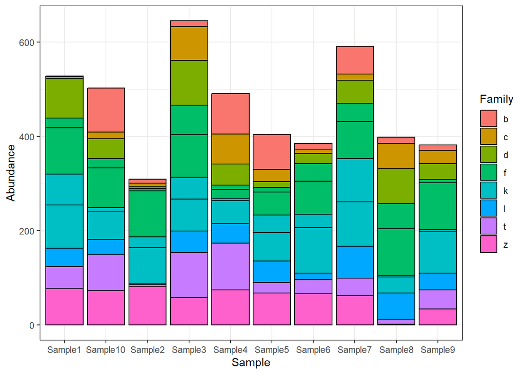

```r
# abundance at the Family level
plot_bar(physeq, fill = "Family") + theme_bw()
```

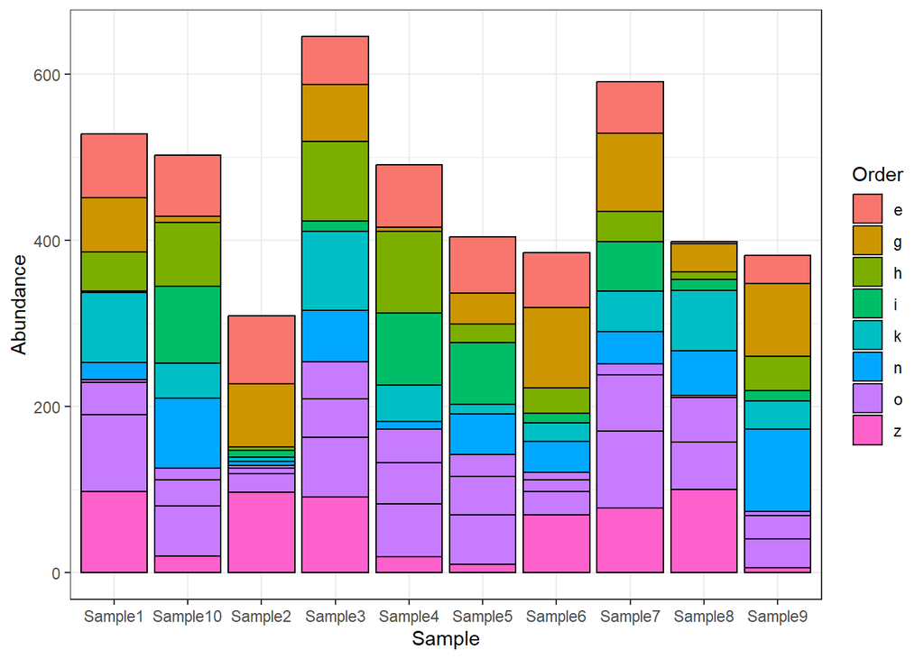

```r
# abundance at the order level
plot_bar(physeq, fill = "Order") + theme_bw()
```

## **Distance and Plotting Ordination**

Phyloseq is able to calculate both distance (measures of dissimilarity) and ordination (visualizing clusters).

This package can calculate 44 supported distance methods, found by the format ** distance(physeq, “method”) **, where physeq is a phyloseq object and method is the distance metric.

We can also plot ordination to measure genetic clustering! Before plotting actual data, it is in best practice to filter OTUs to remove noise and make a cleaner plot. There are 4 main types of ordination plots: 1) OTUs, 2) sample information, 3) biplot graphics and 4) split graphics. This tutorial will be plotting only OTUs (option 1).

```r
GP = GlobalPatterns
GP.ord <- ordinate(GP, "NMDS", "bray")
```

```
## Square root transformation
## Wisconsin double standardization
## *** Best solution repeated 1 times
```

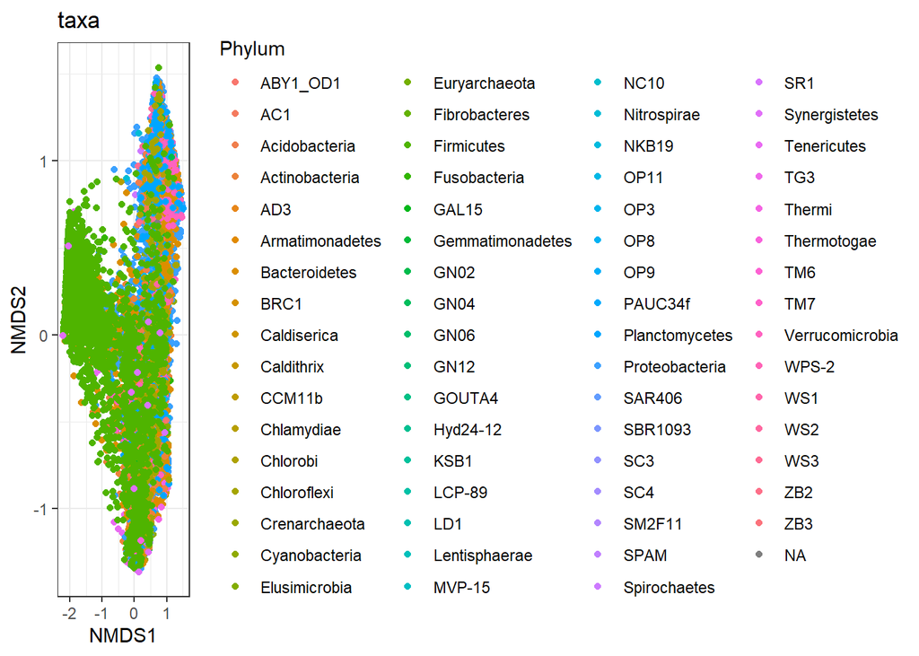

```r
p1 = plot_ordination(GP, GP.ord, type="taxa", color="Phylum", title="taxa") + theme_bw()
print(p1)
```

Since this is incredibly crowded, we are going to filter out OTUs that appear less than 5 times in more than half samples.

```r
wh0 = genefilter_sample(GP, filterfun_sample(function(x) x > 5), A=0.5*nsamples(GP))
GP1 = prune_taxa(wh0, GP)

GP.ord1 <- ordinate(GP1, "NMDS", "bray")
```

```
## Square root transformation
## Wisconsin double standardization
## *** Best solution repeated 1 times
```

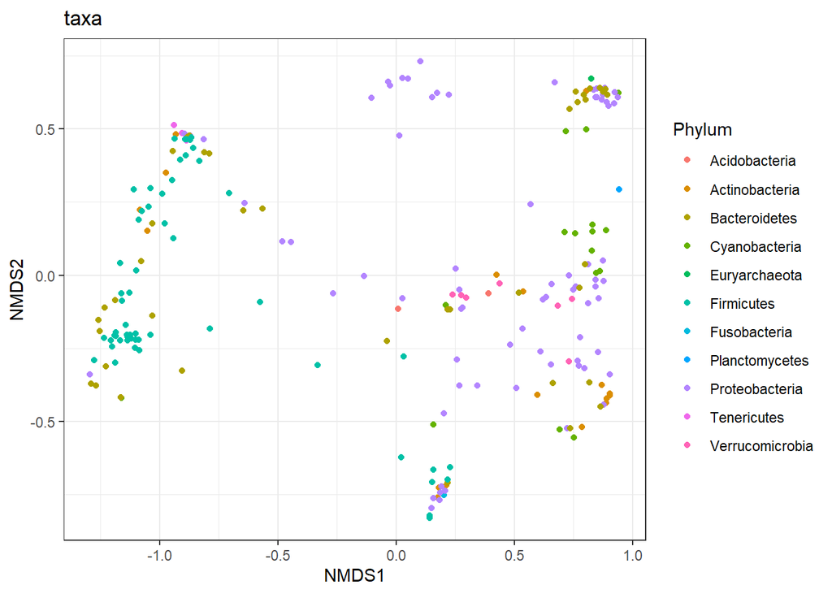

```r
p2 = plot_ordination(GP1, GP.ord1, type="taxa", color="Phylum", title="taxa") + theme_bw()
print(p2)
```

**Code to construct phyloseq object**:

data(“GlobalPatterns”) library(phyloseq) library(ggplot2)

otu.matrix <- matrix(sample(1:100, 100, replace=T), nrow=10, ncol=10)

rownames(otu.matrix) <- paste0(“OTU”, 1:nrow(otu.matrix))

colnames(otu.matrix) <- paste0(“Sample”, 1:ncol(otu.matrix))

tax.matrix <- matrix(sample(letters, 70, replace=T), nrow=nrow(otu.matrix), ncol=7)

rownames(tax.matrix) <- rownames(otu.matrix)

colnames(tax.matrix) <- c(“Domain”, “Phylum”, “Class”, “Order”, “Family”, “Genus”, “Species”)

otu <- otu_table(otu.matrix, taxa_are_rows = TRUE)

tax <- tax_table(tax.matrix)

physeq <- phyloseq(otu, tax)

physeq